# McDonald's Assignment

## Import all the necessary libraries

```python
import numpy as np
import pandas as pd
import seaborn as sns
import matplotlib.pyplot as plt
sns.set(color_codes=True)
%matplotlib inline
import seaborn as sns
import scipy.stats as stats
sns.set() #setting the default seaborn style for our plots
import os
from warnings import filterwarnings
filterwarnings("ignore")
```

[figure not shown]

## Read the data into the notebook

```python
df = pd.read_csv('Mcdonald .csv') # read the data as DataFrame
```

```python
#checking the head of the data frame
df.head()
```

|  | Category | Item | Serving Size | Calories | Calories from Fat | Total Fat | Total Fat (% Daily Value) | Saturated Fat | Saturated Fat (% Daily Value) | Trans Fat | ... | Carbohydrates | Carbohydrates (% Daily Value) | Dietary Fiber | Dietary Fiber (% Daily Value) | Sugars | Protein | Vitamin A (% Daily Value) | Vitamin C (% Daily Value) | Calcium (% Daily Value) | Iron (% Daily Value) |
| --- | --- | --- | --- | --- | --- | --- | --- | --- | --- | --- | --- | --- | --- | --- | --- | --- | --- | --- | --- | --- | --- |
| 0 | Breakfast | Egg McMuffin | 4.8 oz (136 g) | 300 | 120 | 13.0 | 20 | 5.0 | 25 | 0.0 | ... | 31 | 10 | 4 | 17 | 3 | 17 | 10 | 0 | 25 | 15 |
| 1 | Breakfast | Egg White Delight | 4.8 oz (135 g) | 250 | 70 | 8.0 | 12 | 3.0 | 15 | 0.0 | ... | 30 | 10 | 4 | 17 | 3 | 18 | 6 | 0 | 25 | 8 |
| 2 | Breakfast | Sausage McMuffin | 3.9 oz (111 g) | 370 | 200 | 23.0 | 35 | 8.0 | 42 | 0.0 | ... | 29 | 10 | 4 | 17 | 2 | 14 | 8 | 0 | 25 | 10 |
| 3 | Breakfast | Sausage McMuffin with Egg | 5.7 oz (161 g) | 450 | 250 | 28.0 | 43 | 10.0 | 52 | 0.0 | ... | 30 | 10 | 4 | 17 | 2 | 21 | 15 | 0 | 30 | 15 |
| 4 | Breakfast | Sausage McMuffin with Egg Whites | 5.7 oz (161 g) | 400 | 210 | 23.0 | 35 | 8.0 | 42 | 0.0 | ... | 30 | 10 | 4 | 17 | 2 | 21 | 6 | 0 | 25 | 10 |

5 rows × 24 columns

## Basic EDA

- Find the shape of the data,data type of individual columns
- Check the presence of missing values
- Descriptive stats of numerical columns

```python
 #info about the data
df.info()
```

```
<class 'pandas.core.frame.DataFrame'>
RangeIndex: 260 entries, 0 to 259
Data columns (total 24 columns):
 #   Column                         Non-Null Count  Dtype
---  ------                         --------------  -----
 0   Category                       260 non-null    object
 1   Item                           260 non-null    object
 2   Serving Size                   260 non-null    object
 3   Calories                       260 non-null    int64
 4   Calories from Fat              260 non-null    int64
 5   Total Fat                      260 non-null    float64
 6   Total Fat (% Daily Value)      260 non-null    int64
 7   Saturated Fat                  260 non-null    float64
 8   Saturated Fat (% Daily Value)  260 non-null    int64
 9   Trans Fat                      260 non-null    float64
```

[output cut: 16 more lines]

### - The data has 260 instances with 24 attributes.

-18 integer type, 3 float type and 3 object type(Strings in the column)

```python
#check the shape of the data
df.shape
```

```
(260, 24)
```

# Check for missing value

```python
# Check for missing value in any column
df.isnull().sum()
```

```
Category                         0
Item                             0
Serving Size                     0
Calories                         0
Calories from Fat                0
Total Fat                        0
Total Fat (% Daily Value)        0
Saturated Fat                    0
Saturated Fat (% Daily Value)    0
Trans Fat                        0
Cholesterol                      0
Cholesterol (% Daily Value)      0
Sodium                           0
Sodium (% Daily Value)           0
Carbohydrates                    0
Carbohydrates (% Daily Value)    0
Dietary Fiber                    0
Dietary Fiber (% Daily Value)    0
Sugars                           0
Protein                          0
Vitamin A (% Daily Value)        0
Vitamin C (% Daily Value)        0
Calcium (% Daily Value)          0
Iron (% Daily Value)             0
dtype: int64
```

```python
df.isnull().values.any()
```

```
False
```

```python
df.isnull().sum().sum()
```

```
0
```

# Checking the summary of dataframe

```python
df.describe(include='all').T
```

|  | count | unique | top | freq | mean | std | min | 25% | 50% | 75% | max |
| --- | --- | --- | --- | --- | --- | --- | --- | --- | --- | --- | --- |
| Category | 260 | 9 | Coffee & Tea | 95 | NaN | NaN | NaN | NaN | NaN | NaN | NaN |
| Item | 260 | 260 | Strawberry Banana Smoothie (Small) | 1 | NaN | NaN | NaN | NaN | NaN | NaN | NaN |
| Serving Size | 260 | 107 | 16 fl oz cup | 45 | NaN | NaN | NaN | NaN | NaN | NaN | NaN |
| Calories | 260.0 | NaN | NaN | NaN | 368.269231 | 240.269886 | 0.0 | 210.0 | 340.0 | 500.0 | 1880.0 |
| Calories from Fat | 260.0 | NaN | NaN | NaN | 127.096154 | 127.875914 | 0.0 | 20.0 | 100.0 | 200.0 | 1060.0 |
| Total Fat | 260.0 | NaN | NaN | NaN | 14.165385 | 14.205998 | 0.0 | 2.375 | 11.0 | 22.25 | 118.0 |
| Total Fat (% Daily Value) | 260.0 | NaN | NaN | NaN | 21.815385 | 21.885199 | 0.0 | 3.75 | 17.0 | 35.0 | 182.0 |
| Saturated Fat | 260.0 | NaN | NaN | NaN | 6.007692 | 5.321873 | 0.0 | 1.0 | 5.0 | 10.0 | 20.0 |
| Saturated Fat (% Daily Value) | 260.0 | NaN | NaN | NaN | 29.965385 | 26.639209 | 0.0 | 4.75 | 24.0 | 48.0 | 102.0 |
| Trans Fat | 260.0 | NaN | NaN | NaN | 0.203846 | 0.429133 | 0.0 | 0.0 | 0.0 | 0.0 | 2.5 |
| Cholesterol | 260.0 | NaN | NaN | NaN | 54.942308 | 87.269257 | 0.0 | 5.0 | 35.0 | 65.0 | 575.0 |
| Cholesterol (% Daily Value) | 260.0 | NaN | NaN | NaN | 18.392308 | 29.091653 | 0.0 | 2.0 | 11.0 | 21.25 | 192.0 |
| Sodium | 260.0 | NaN | NaN | NaN | 495.75 | 577.026323 | 0.0 | 107.5 | 190.0 | 865.0 | 3600.0 |
| Sodium (% Daily Value) | 260.0 | NaN | NaN | NaN | 20.676923 | 24.034954 | 0.0 | 4.75 | 8.0 | 36.25 | 150.0 |
| Carbohydrates | 260.0 | NaN | NaN | NaN | 47.346154 | 28.252232 | 0.0 | 30.0 | 44.0 | 60.0 | 141.0 |
| Carbohydrates (% Daily Value) | 260.0 | NaN | NaN | NaN | 15.780769 | 9.419544 | 0.0 | 10.0 | 15.0 | 20.0 | 47.0 |
| Dietary Fiber | 260.0 | NaN | NaN | NaN | 1.630769 | 1.567717 | 0.0 | 0.0 | 1.0 | 3.0 | 7.0 |
| Dietary Fiber (% Daily Value) | 260.0 | NaN | NaN | NaN | 6.530769 | 6.307057 | 0.0 | 0.0 | 5.0 | 10.0 | 28.0 |
| Sugars | 260.0 | NaN | NaN | NaN | 29.423077 | 28.679797 | 0.0 | 5.75 | 17.5 | 48.0 | 128.0 |
| Protein | 260.0 | NaN | NaN | NaN | 13.338462 | 11.426146 | 0.0 | 4.0 | 12.0 | 19.0 | 87.0 |
| Vitamin A (% Daily Value) | 260.0 | NaN | NaN | NaN | 13.426923 | 24.366381 | 0.0 | 2.0 | 8.0 | 15.0 | 170.0 |
| Vitamin C (% Daily Value) | 260.0 | NaN | NaN | NaN | 8.534615 | 26.345542 | 0.0 | 0.0 | 0.0 | 4.0 | 240.0 |
| Calcium (% Daily Value) | 260.0 | NaN | NaN | NaN | 20.973077 | 17.019953 | 0.0 | 6.0 | 20.0 | 30.0 | 70.0 |
| Iron (% Daily Value) | 260.0 | NaN | NaN | NaN | 7.734615 | 8.723263 | 0.0 | 0.0 | 4.0 | 15.0 | 40.0 |

# Q1-Plot graphically which food categories have the highest and lowest varieties.

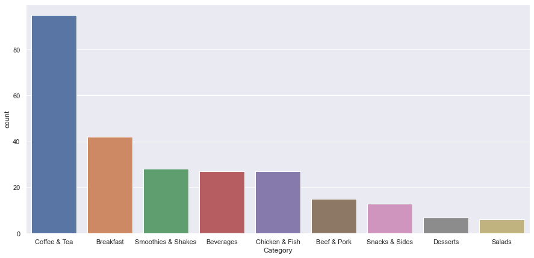

```python
plt.figure(figsize = (15,7))
sns.countplot(df['Category'],order =df['Category'].value_counts().index)
plt.show()
```

### - The food categories which has highest and lowest varieties are Coffee/Tea and Salads respectively.

```python
df['Category'].value_counts()
```

```
Coffee & Tea          95
Breakfast             42
Smoothies & Shakes    28
Beverages             27
Chicken & Fish        27
Beef & Pork           15
Snacks & Sides        13
Desserts               7
Salads                 6
Name: Category, dtype: int64
```

# Q2-Which all variables have an outlier?

Box plot will be plotted to check for outliers.

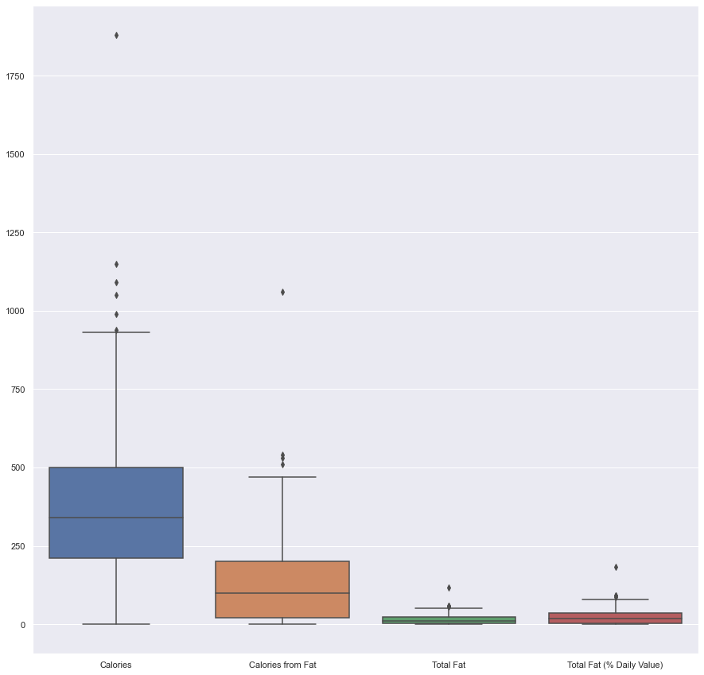

```python
plt.figure(figsize=(15,15))
sns.boxplot( data= df[['Calories', 'Calories from Fat', 'Total Fat', 'Total Fat (% Daily Value)']]);
plt.show()
```

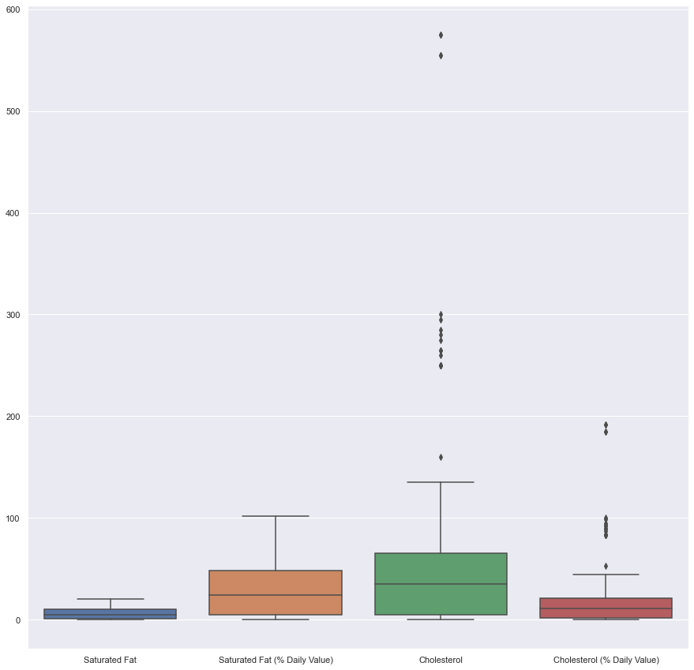

```python
plt.figure(figsize=(15,15))
sns.boxplot( data= df[['Saturated Fat', 'Saturated Fat (% Daily Value)', 'Cholesterol', 'Cholesterol (% Daily Value)']]);
plt.show()
```

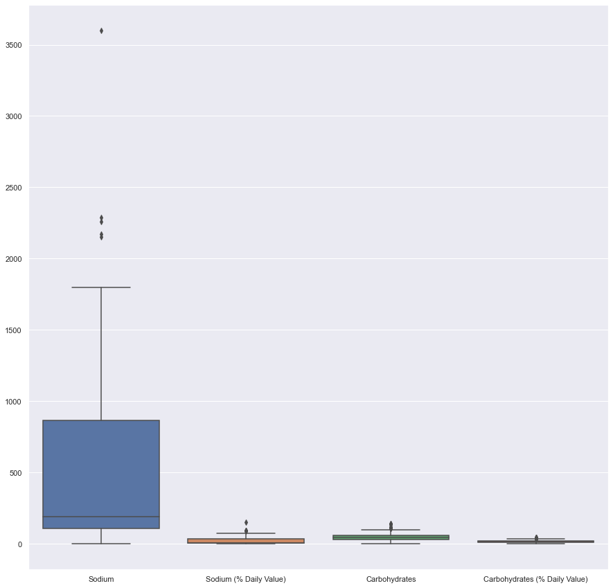

```python
plt.figure(figsize=(15,15))
sns.boxplot( data= df[['Sodium', 'Sodium (% Daily Value)', 'Carbohydrates', 'Carbohydrates (% Daily Value)']]);
plt.show()
```

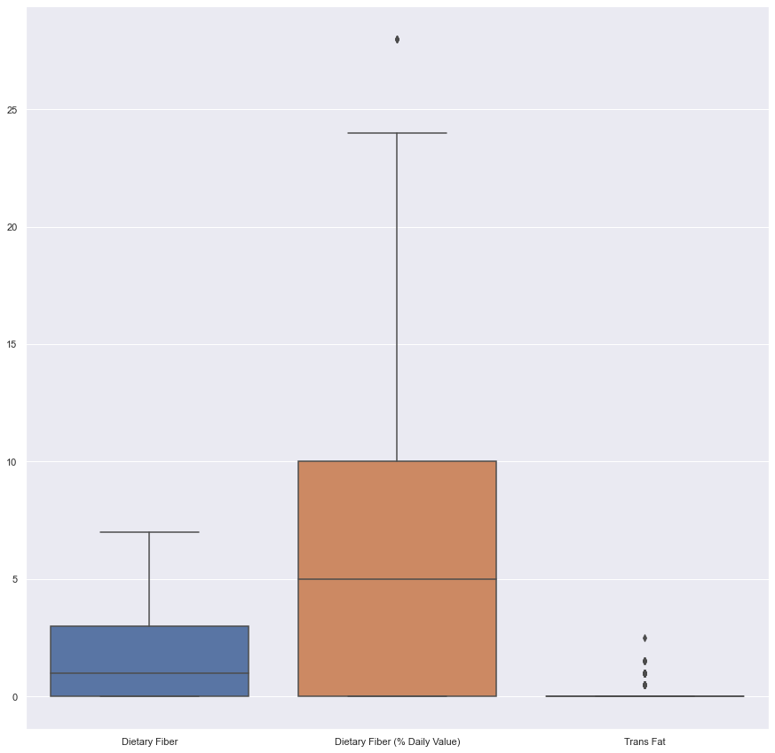

```python
plt.figure(figsize=(15,15))
sns.boxplot( data= df[['Dietary Fiber', 'Dietary Fiber (% Daily Value)', 'Trans Fat']]);
plt.show()
```

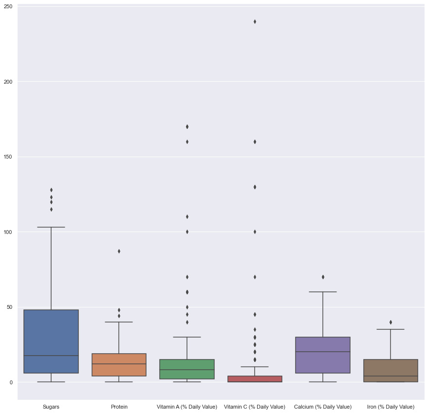

```python
plt.figure(figsize=(15,15))
sns.boxplot( data= df[['Sugars', 'Protein', 'Vitamin A (% Daily Value)', 'Vitamin C (% Daily Value)', 'Calcium (% Daily Value)', 'Iron (% Daily Value)']]);
plt.show()
```

### The columns which have outliers are as follows:

- Calories
- Calories from Fat
- Total Fat
- Total Fat(% Daily Value)
- Cholesterol
- Cholesterol(% Daily Value)
- Sodium
- Sodium (% Daily Value)
- Carbohydrates
- Carbohydrates (% Daily Value)
- Dietary Fiber (% Daily Value)
- Trans Fat
- Sugars
- Protein
- Vitamin A (% Daily Value)
- Vitamin C (% Daily Value)
- Calcium ( % Daily Value)
- Iron ( % Daily Value)

### The columns which do not have outliers are as follows:

- Saturated Fat
- Saturated Fat(% Daily Value)
- Dietary Fiber